Load the required packages and set a seed for the random number generator.

```r
library(tidyverse)

library(rstan)
# set cores to use to the total number of cores (minimally 4)
options(mc.cores = max(parallel::detectCores(), 4))
# save a compiled version of the Stan model file
rstan_options(auto_write = TRUE)

library(brms)

# install faintr with devtools::install_github('michael-franke/bayes_mixed_regression_tutorial/faintr', build_vignettes = TRUE)
library(faintr)

set.seed(123)
```

Read the data:

```r
raw_data = read_csv("results.csv")
glimpse(raw_data)
```

```
## Observations: 27,685
## Variables: 29
## $ submission_id <dbl> 605, 605, 605, 605, 605, 605, 605, 605, 605, 605, …
## $ QUD           <lgl> NA, NA, NA, NA, NA, NA, NA, NA, NA, NA, NA, NA, NA…
## $ RT            <dbl> 15344, 8314, 65189, 10070, 5679, 2714, 4583, 2000,…
## $ age           <dbl> 23, 23, 23, 23, 23, 23, 23, 23, 23, 23, 23, 23, 23…
## $ artist        <chr> NA, NA, NA, "P", "B", "G", "G", "P", "P", "P", "G"…
## $ color         <chr> NA, NA, NA, "colored", "monochrome", "colored", "c…
## $ color2        <chr> NA, NA, NA, "sepia", "monochrome", "colored", "col…
## $ comments      <lgl> NA, NA, NA, NA, NA, NA, NA, NA, NA, NA, NA, NA, NA…
## $ date          <dbl> NA, NA, NA, 1910, 1911, 1915, 1912, 1911, 1911, 19…
## $ education     <chr> "Graduated College", "Graduated College", "Graduat…
## $ endTime       <dbl> 1.563018e+12, 1.563018e+12, 1.563018e+12, 1.563018…
## $ expected      <chr> "74", "7", "FELOPZD", NA, NA, NA, NA, NA, NA, NA, …
## $ experiment_id <dbl> 77, 77, 77, 77, 77, 77, 77, 77, 77, 77, 77, 77, 77…
```

[output cut: 16 more lines]

Rename variables

```r
data = rename(raw_data,
  submissionID = `submission_id`,
  trialName = `trial_name`
)

glimpse(data)
```

```
## Observations: 27,685
## Variables: 29
## $ submissionID  <dbl> 605, 605, 605, 605, 605, 605, 605, 605, 605, 605, …
## $ QUD           <lgl> NA, NA, NA, NA, NA, NA, NA, NA, NA, NA, NA, NA, NA…
## $ RT            <dbl> 15344, 8314, 65189, 10070, 5679, 2714, 4583, 2000,…
## $ age           <dbl> 23, 23, 23, 23, 23, 23, 23, 23, 23, 23, 23, 23, 23…
## $ artist        <chr> NA, NA, NA, "P", "B", "G", "G", "P", "P", "P", "G"…
## $ color         <chr> NA, NA, NA, "colored", "monochrome", "colored", "c…
## $ color2        <chr> NA, NA, NA, "sepia", "monochrome", "colored", "col…
## $ comments      <lgl> NA, NA, NA, NA, NA, NA, NA, NA, NA, NA, NA, NA, NA…
## $ date          <dbl> NA, NA, NA, 1910, 1911, 1915, 1912, 1911, 1911, 19…
## $ education     <chr> "Graduated College", "Graduated College", "Graduat…
## $ endTime       <dbl> 1.563018e+12, 1.563018e+12, 1.563018e+12, 1.563018…
## $ expected      <chr> "74", "7", "FELOPZD", NA, NA, NA, NA, NA, NA, NA, …
## $ experiment_id <dbl> 77, 77, 77, 77, 77, 77, 77, 77, 77, 77, 77, 77, 77…
```

[output cut: 16 more lines]

Select only the variables that are important for the analysis:

```r
data = select(data, submissionID, trialName,
         response, pictureNumber, artist, date,
         age, gender, timeSpent, color, color2)

glimpse(data)
```

```
## Observations: 27,685
## Variables: 11
## $ submissionID  <dbl> 605, 605, 605, 605, 605, 605, 605, 605, 605, 605, …
## $ trialName     <chr> "colourVisionTest1", "colourVisionTest2", "visionT…
## $ response      <chr> "74", "7", "FELOPZD", "4", "5", "3", "4", "3", "3"…
## $ pictureNumber <dbl> 0, 0, 0, 32, 65, 75, 84, 56, 71, 120, 89, 46, 16, …
## $ artist        <chr> NA, NA, NA, "P", "B", "G", "G", "P", "P", "P", "G"…
## $ date          <dbl> NA, NA, NA, 1910, 1911, 1915, 1912, 1911, 1911, 19…
## $ age           <dbl> 23, 23, 23, 23, 23, 23, 23, 23, 23, 23, 23, 23, 23…
## $ gender        <chr> "female", "female", "female", "female", "female", …
## $ timeSpent     <dbl> 13.91613, 13.91613, 13.91613, 13.91613, 13.91613, …
## $ color         <chr> NA, NA, NA, "colored", "monochrome", "colored", "c…
## $ color2        <chr> NA, NA, NA, "sepia", "monochrome", "colored", "col…
```

Exclude participants from the data that we don’t want to have. Also find out why we had to exclude them.

```r
data_ex <- data

fehlerCV1 = 0
fehlerCV2 = 0
fehlerV = 0
fehlerExp = 0
fehlerT = 0
fehlerXP = 0


for(i in 1:(nrow(data) / 245)) {

  # colorVisionTest1
  if(data[((i - 1)*245 + 1), ]$response != "74") {
    data_ex = filter(data_ex, submissionID != data[((i - 1)*245 + 1), ]$submissionID)

    fehlerCV1 = fehlerCV1 + 1

  # colorVisionTest2
  } else if(data[((i - 1)*245 + 2), ]$response != "7") {
    data_ex = filter(data_ex, submissionID != data[((i - 1)*245 + 2), ]$submissionID)

     fehlerCV2 = fehlerCV2 + 1

  # visionTest
  } else if(data[((i - 1)*245 + 3), ]$response != "FELOPZD") {
    data_ex = filter(data_ex, submissionID != data[((i - 1)*245 + 3), ]$submissionID)

     fehlerV = fehlerV + 1

  # expertise
  } else if(as.integer(data[((i - 1)*245 + 244), ]$response) > 5) {
     data_ex = filter(data_ex, submissionID != data[((i - 1)*245 + 244), ]$submissionID)

      fehlerExp = fehlerExp + 1

  # time spent
  } else if(data[((i - 1)*245 + 1), ]$timeSpent < 5) {
     data_ex = filter(data_ex, submissionID != data[((i - 1)*245 + 1), ]$submissionID)

      fehlerT = fehlerT + 1

  # exclude participants that took part in the course Experimental Psychology Lab
  } else if(data[((i - 1)*245 + 245), ]$response == "Yes") {
    data_ex = filter(data_ex, submissionID != data[((i - 1)*245 + 245), ]$submissionID)

     fehlerXP = fehlerXP + 1

  }

}

glimpse(data_ex)
```

```
## Observations: 15,680
## Variables: 11
## $ submissionID  <dbl> 605, 605, 605, 605, 605, 605, 605, 605, 605, 605, …
## $ trialName     <chr> "colourVisionTest1", "colourVisionTest2", "visionT…
## $ response      <chr> "74", "7", "FELOPZD", "4", "5", "3", "4", "3", "3"…
## $ pictureNumber <dbl> 0, 0, 0, 32, 65, 75, 84, 56, 71, 120, 89, 46, 16, …
## $ artist        <chr> NA, NA, NA, "P", "B", "G", "G", "P", "P", "P", "G"…
## $ date          <dbl> NA, NA, NA, 1910, 1911, 1915, 1912, 1911, 1911, 19…
## $ age           <dbl> 23, 23, 23, 23, 23, 23, 23, 23, 23, 23, 23, 23, 23…
## $ gender        <chr> "female", "female", "female", "female", "female", …
## $ timeSpent     <dbl> 13.91613, 13.91613, 13.91613, 13.91613, 13.91613, …
## $ color         <chr> NA, NA, NA, "colored", "monochrome", "colored", "c…
## $ color2        <chr> NA, NA, NA, "sepia", "monochrome", "colored", "col…
```

```r
print(c("Number of excluded participants because of colorVisionTest1: ", fehlerCV1))
```

```
## [1] "Number of excluded participants because of colorVisionTest1: "
## [2] "18"
```

```r
print(c("Number of excluded participants because of colorVisionTest2: ", fehlerCV2))
```

```
## [1] "Number of excluded participants because of colorVisionTest2: "
## [2] "2"
```

```r
print(c("Number of excluded participants because of VisionTest: ", fehlerV))
```

```
## [1] "Number of excluded participants because of VisionTest: "
## [2] "24"
```

```r
print(c("Number of excluded participants because of their expertise level in cubism: ", fehlerExp))
```

```
## [1] "Number of excluded participants because of their expertise level in cubism: "
## [2] "0"
```

```r
print(c("Number of excluded participants because of TimeSpent: ", fehlerT))
```

```
## [1] "Number of excluded participants because of TimeSpent: "
## [2] "0"
```

```r
print(c("Number of excluded participants because of participation in XPLab: ", fehlerXP))
```

```
## [1] "Number of excluded participants because of participation in XPLab: "
## [2] "5"
```

Calculate age mean, age range and gender distribution, number of participants:

```r
data_ex %>% summarise(meanAge = mean(na.exclude(age)))
```

```
## # A tibble: 1 x 1
##   meanAge
##     <dbl>
## 1    29.3
```

```r
gender_distribution = count(data_ex, gender)
gender_distribution$n =  gender_distribution$n / 245

print(c("Age range: ", range(na.exclude(data_ex$age))))
```

```
## [1] "Age range: " "11"          "81"
```

```r
participants = nrow(data) / 245
participants_valid = nrow(data_ex) / 245

print(gender_distribution)
```

```
## # A tibble: 2 x 2
##   gender     n
##   <chr>  <dbl>
## 1 female    40
## 2 male      24
```

```r
print(c("Total number of participants: ", participants))
```

```
## [1] "Total number of participants: " "113"
```

```r
print(c("Number of valid participants: ", participants_valid))
```

```
## [1] "Number of valid participants: " "64"
```

transform the data into right form:

```r
d = filter(data_ex, trialName %in% c("ratingScaleLike",
                                 "ratingScaleDetect")) %>%
  select(submissionID, trialName, pictureNumber, artist, date, response, color, color2) %>%
  spread(key = trialName, value = response)

d$ratingScaleLike <- as.numeric(d$ratingScaleLike)
d$ratingScaleDetect <- as.numeric(d$ratingScaleDetect)

d = rename(d, detectability = ratingScaleDetect, liking = ratingScaleLike)

glimpse(d)
```

```
## Observations: 7,680
## Variables: 8
## $ submissionID  <dbl> 551, 551, 551, 551, 551, 551, 551, 551, 551, 551, …
## $ pictureNumber <dbl> 1, 2, 3, 4, 5, 6, 7, 8, 9, 10, 11, 12, 13, 14, 15,…
## $ artist        <chr> "B", "B", "B", "B", "B", "B", "B", "B", "B", "P", …
## $ date          <dbl> 1909, 1909, 1910, 1910, 1910, 1910, 1913, 1909, 19…
## $ color         <chr> "colored", "colored", "colored", "colored", "color…
## $ color2        <chr> "colored", "sepia", "sepia", "sepia", "colored", "…
## $ detectability <dbl> 6, 5, 4, 2, 3, 2, 2, 6, 2, 2, 5, 2, 4, 4, 7, 2, 1,…
## $ liking        <dbl> 2, 2, 2, 2, 2, 5, 2, 2, 2, 2, 1, 2, 2, 2, 3, 3, 4,…
```

Check that everything is there and of the correct type:

```r
d_tibble <- as_tibble(d)

print(d_tibble)
```

```
## # A tibble: 7,680 x 8
##    submissionID pictureNumber artist  date color color2 detectability
##           <dbl>         <dbl> <chr>  <dbl> <chr> <chr>          <dbl>
##  1          551             1 B       1909 colo… color…             6
##  2          551             2 B       1909 colo… sepia              5
##  3          551             3 B       1910 colo… sepia              4
##  4          551             4 B       1910 colo… sepia              2
##  5          551             5 B       1910 colo… color…             3
##  6          551             6 B       1910 colo… sepia              2
##  7          551             7 B       1913 colo… color…             2
##  8          551             8 B       1909 colo… color…             6
##  9          551             9 B       1911 colo… sepia              2
## 10          551            10 P       1912 colo… color…             2
## # … with 7,670 more rows, and 1 more variable: liking <dbl>
```

inspect the data with x = detectability and y = liking for the different participants This part is just for our interest.

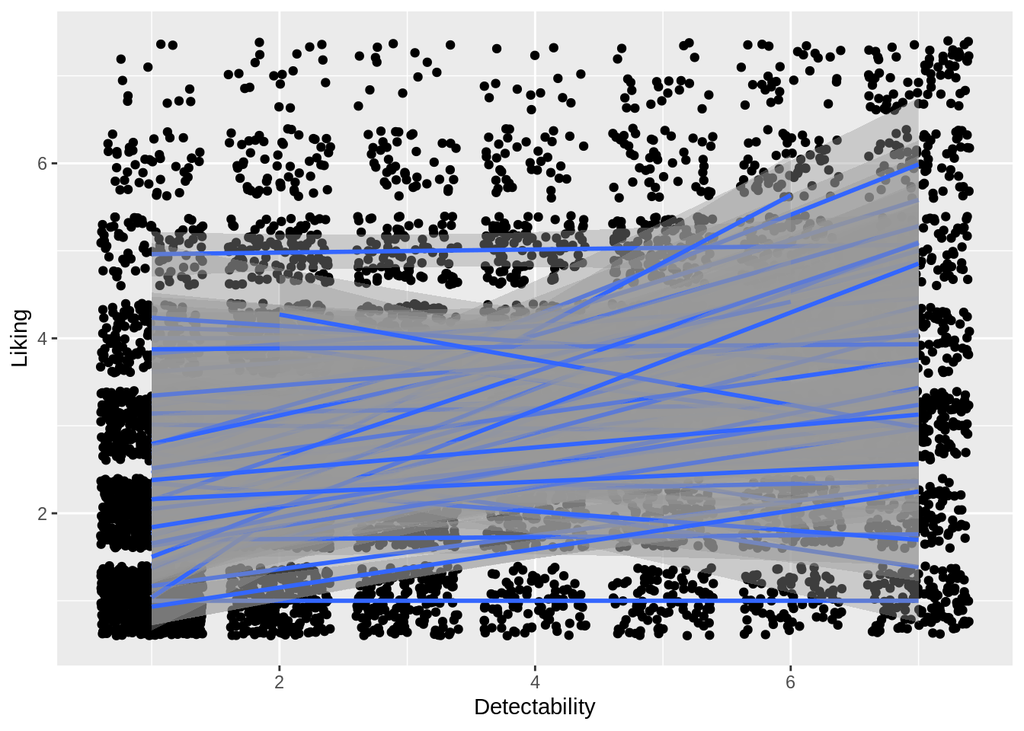

```r
ggplot(d, aes(x = detectability, y = liking, group = submissionID)) + geom_jitter() + geom_smooth(method = "lm") + labs(x = "Detectability", y = "Liking")
```

inspect the data x = detectability and y = liking

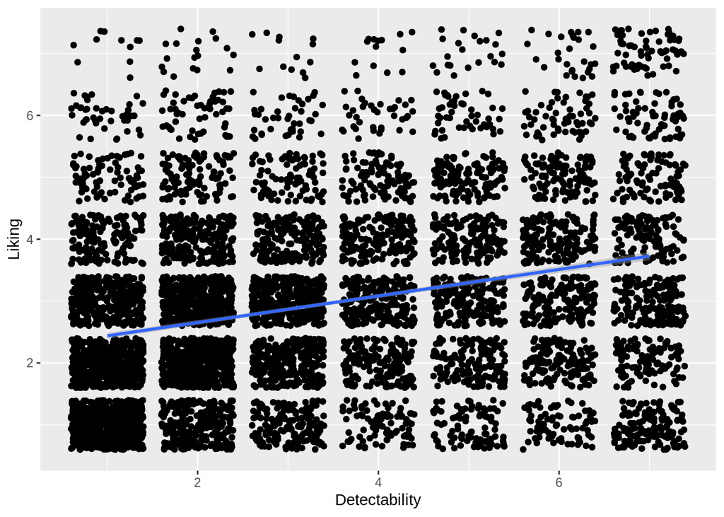

```r
ggplot(d, aes(x = detectability, y = liking)) + geom_jitter() + geom_smooth(method = "lm") + labs(x = "Detectability", y = "Liking")
```

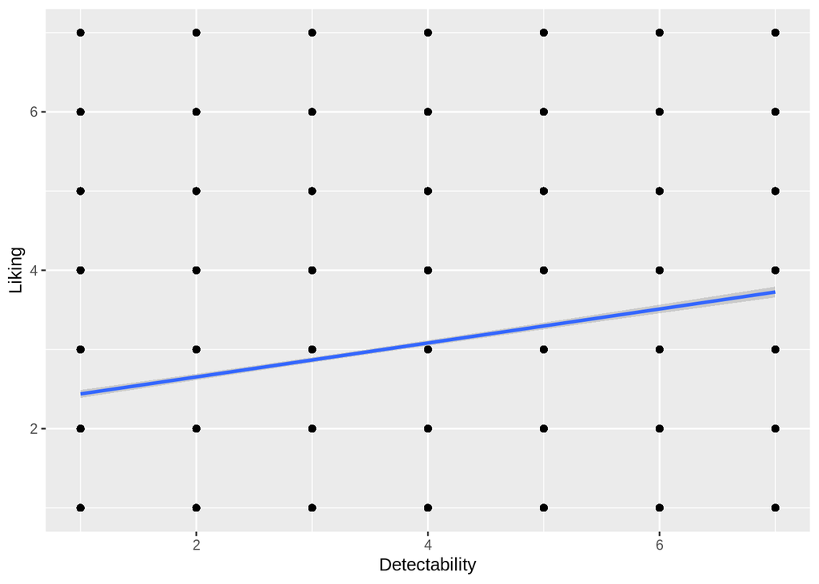

```r
ggplot(d, aes(x = detectability, y = liking)) + geom_point() + geom_smooth(method = "lm") + labs(x = "Detectability", y = "Liking")
```

Boxplots that shows liking and detectability

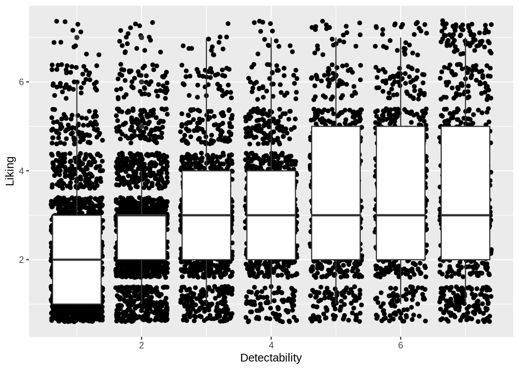

```r
ggplot(d, aes(x = detectability, y = liking, group = detectability)) + geom_jitter() + geom_boxplot() + labs(x = "Detectability", y = "Liking")
```

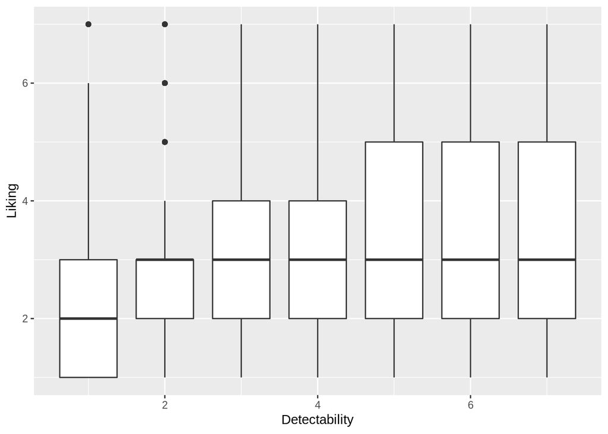

```r
ggplot(d, aes(x = detectability, y = liking, group = detectability)) + geom_boxplot() + labs(x = "Detectability", y = "Liking")
```

calculate means for detectability:

```r
d %>% group_by(liking) %>% summarise(meanDetect = mean(detectability))
```

```
## # A tibble: 7 x 2
##   liking meanDetect
##    <dbl>      <dbl>
## 1      1       2.68
## 2      2       2.88
## 3      3       3.37
## 4      4       3.74
## 5      5       4.12
## 6      6       4.28
## 7      7       5.13
```

calculate means for liking:

```r
d %>% group_by(detectability) %>% summarise(meanLike = mean(liking))
```

```
## # A tibble: 7 x 2
##   detectability meanLike
##           <dbl>    <dbl>
## 1             1     2.27
## 2             2     2.75
## 3             3     2.95
## 4             4     3.23
## 5             5     3.40
## 6             6     3.51
## 7             7     3.49
```

calculate means for different artists:

```r
d %>% group_by(artist) %>% summarise(meanLike = mean(liking), meanDetect = mean(detectability))
```

```
## # A tibble: 3 x 3
##   artist meanLike meanDetect
##   <chr>     <dbl>      <dbl>
## 1 B          2.71       2.69
## 2 G          3.36       4.78
## 3 P          2.74       2.53
```

Boxplots and graphs that show liking and detectability (for the different artists)

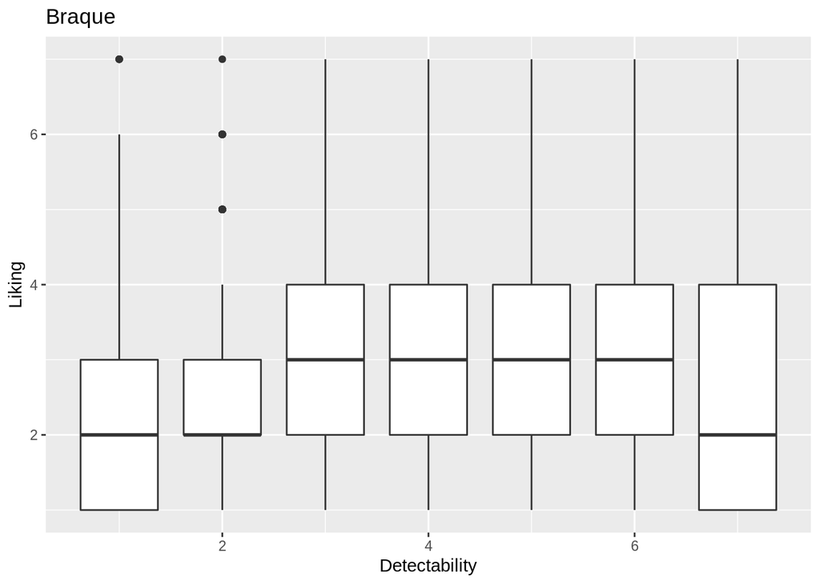

```r
dataB <- d %>% filter(artist == "B")
dataP <- d %>% filter(artist == "P")
dataG <- d %>% filter(artist == "G")

ggplot(dataB, aes(x = detectability, y = liking, group = detectability)) + geom_boxplot() + labs(x = "Detectability", y = "Liking", title = "Braque")
```

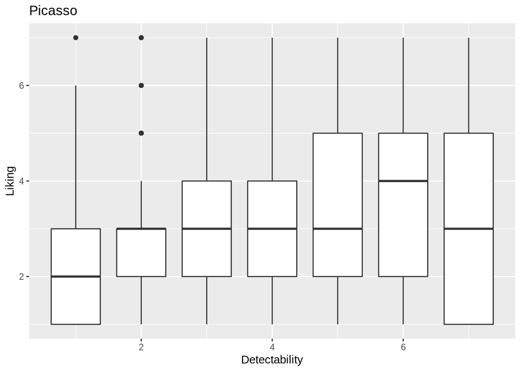

```r
ggplot(dataP, aes(x = detectability, y = liking, group = detectability)) + geom_boxplot() + labs(x = "Detectability", y = "Liking", title = "Picasso")
```

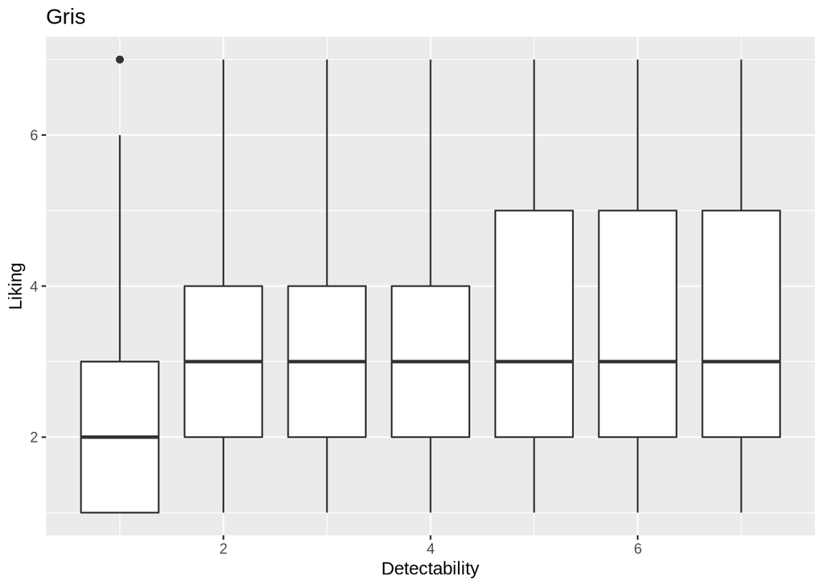

```r
ggplot(dataG, aes(x = detectability, y = liking, group = detectability)) + geom_boxplot() + labs(x = "Detectability", y = "Liking", title = "Gris")
```

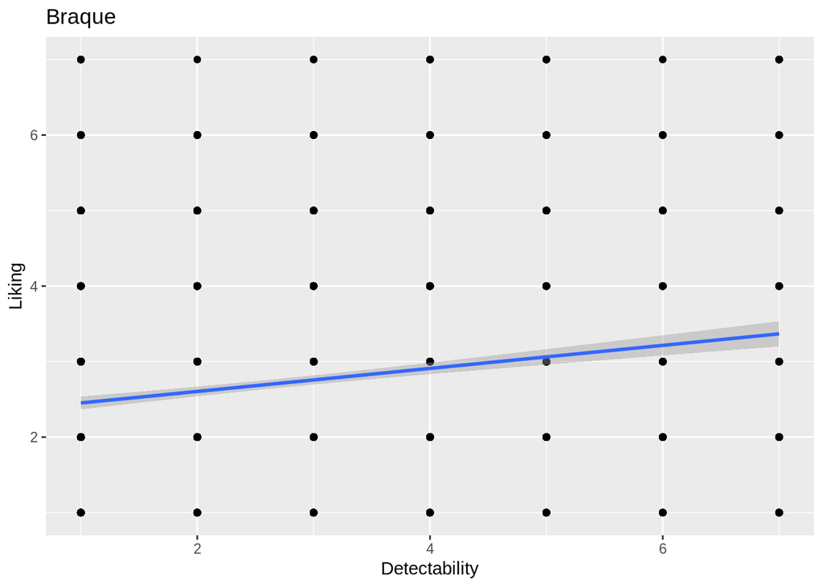

```r
ggplot(dataB, aes(x = detectability, y = liking)) + geom_point() + geom_smooth(method = "lm") + labs(x = "Detectability", y = "Liking", title = "Braque")
```

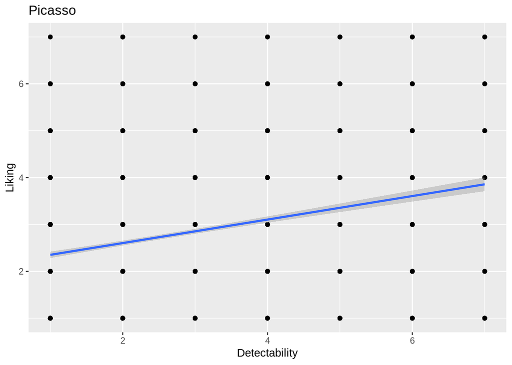

```r
ggplot(dataP, aes(x = detectability, y = liking)) + geom_point() + geom_smooth(method = "lm") + labs(x = "Detectability", y = "Liking", title = "Picasso")
```

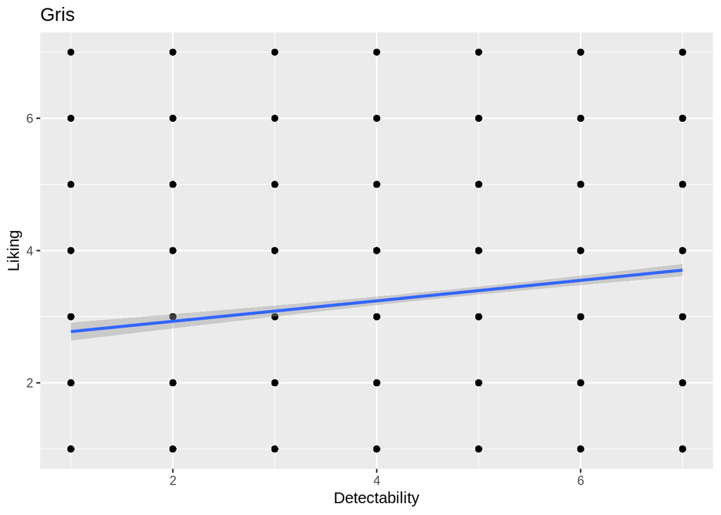

```r
ggplot(dataG, aes(x = detectability, y = liking)) + geom_point() + geom_smooth(method = "lm") + labs(x = "Detectability", y = "Liking", title = "Gris")
```

Graphs / boxplots that show liking and detectability (for the different artists in one graph / boxplot)

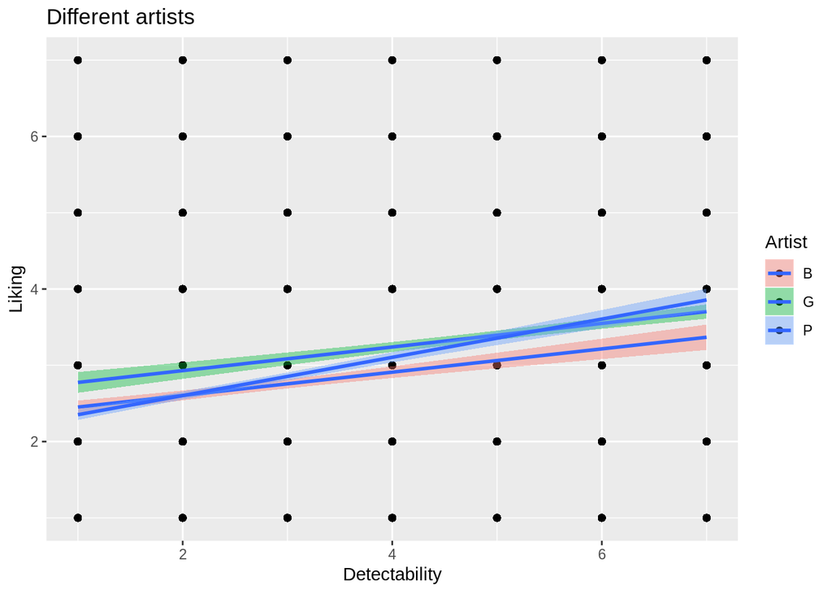

```r
ggplot(d, aes(x = detectability, y = liking, fill = artist)) + geom_point() + geom_smooth(method = "lm") + labs(x = "Detectability", y = "Liking", title = "Different artists", fill = "Artist")
```

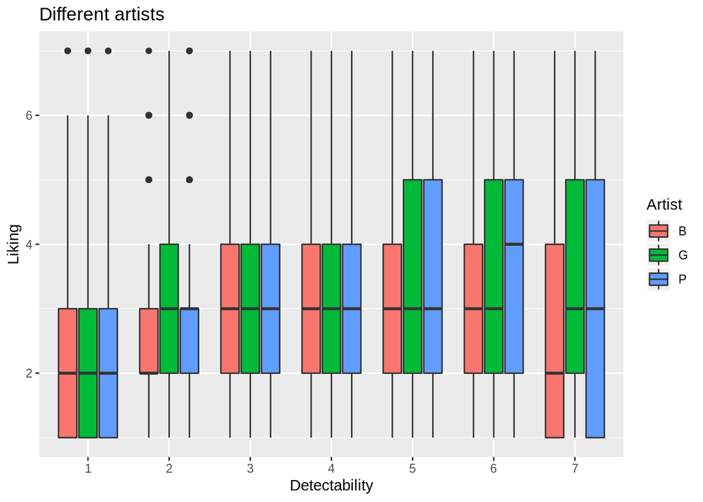

```r
ggplot(d, aes(x = as.factor(detectability), y = liking, fill = artist)) + geom_boxplot()  + labs(x = "Detectability", y = "Liking", title = "Different artists", fill = "Artist")
```

Graphs / boxplots that show liking and detectability (for the color vs. monochrome in one graph / boxplot)

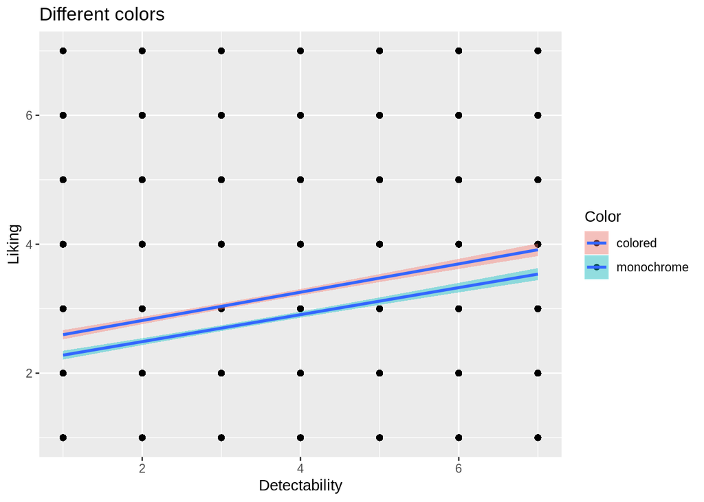

```r
ggplot(d, aes(x = detectability, y = liking, fill = color)) + geom_point() + geom_smooth(method = "lm" ) + labs(x = "Detectability", y = "Liking", title = "Different colors", fill = "Color")
```

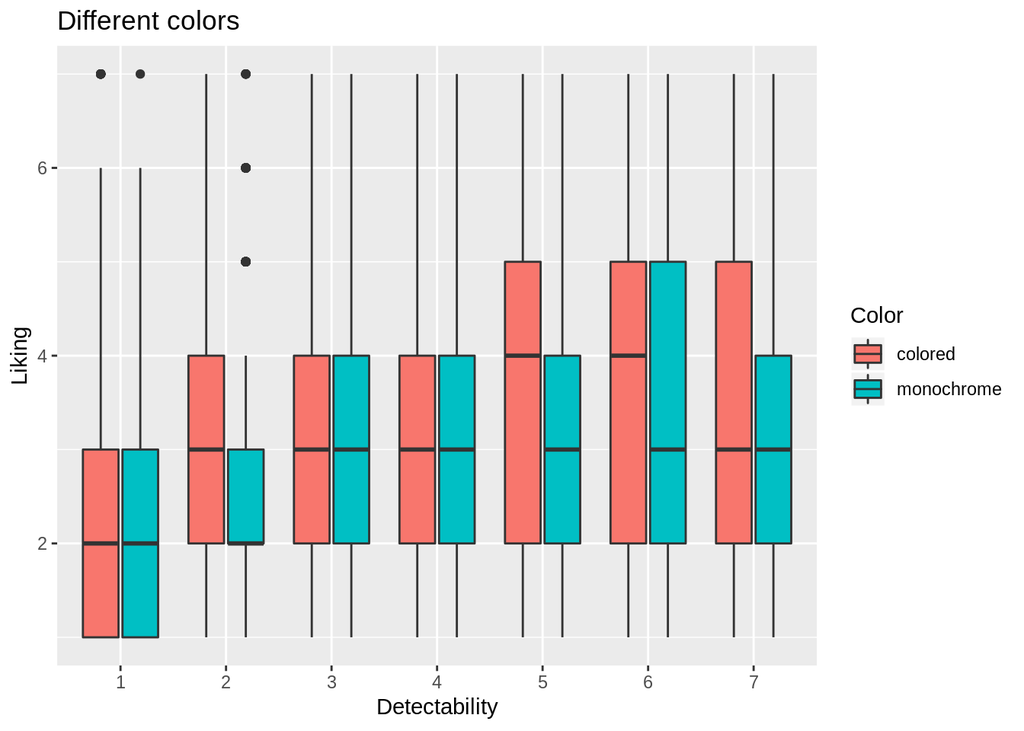

```r
ggplot(d, aes(x = as.factor(detectability), y = liking, fill = color)) + geom_boxplot() + labs(x = "Detectability", y = "Liking", title = "Different colors", fill = "Color")
```

Graphs / boxplots that show liking and detectability (for the color vs. monochrome vs. sepia in one graph / boxplot)

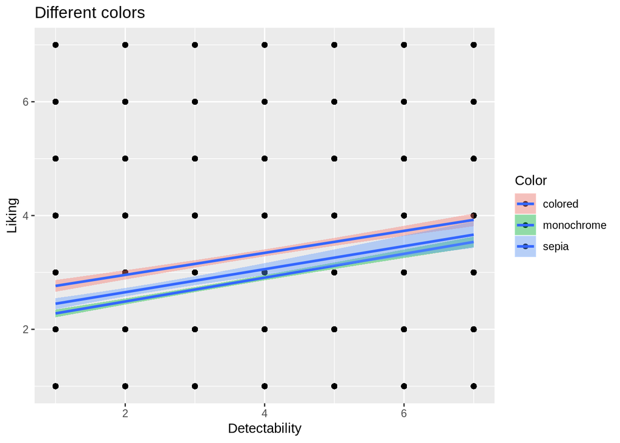

```r
ggplot(d, aes(x = detectability, y = liking, fill = color2)) + geom_point() + geom_smooth(method = "lm") + labs(x = "Detectability", y = "Liking", title = "Different colors", fill = "Color")
```

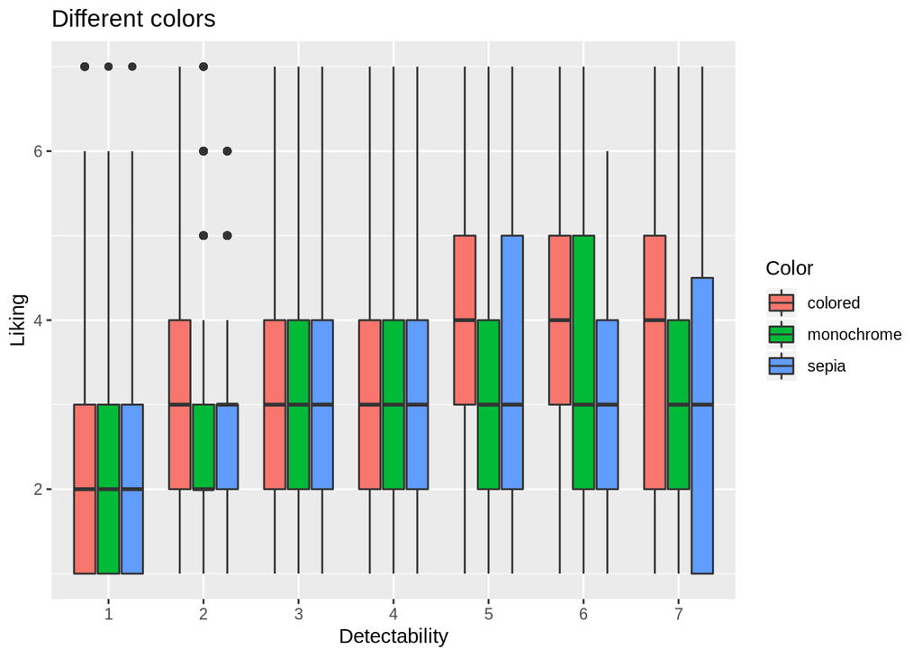

```r
ggplot(d, aes(x = as.factor(detectability), y = liking, fill = color2)) + geom_boxplot() + labs(x = "Detectability", y = "Liking", title = "Different colors", fill = "Color")
```

calculate means for different colors:

```r
d %>% group_by(color2) %>% summarise(meanLike = mean(liking))
```

```
## # A tibble: 3 x 2
##   color2     meanLike
##   <chr>         <dbl>
## 1 colored        3.31
## 2 monochrome     2.77
## 3 sepia          2.73
```

Boxplots and graphs that show liking and detectability (for the different time span)

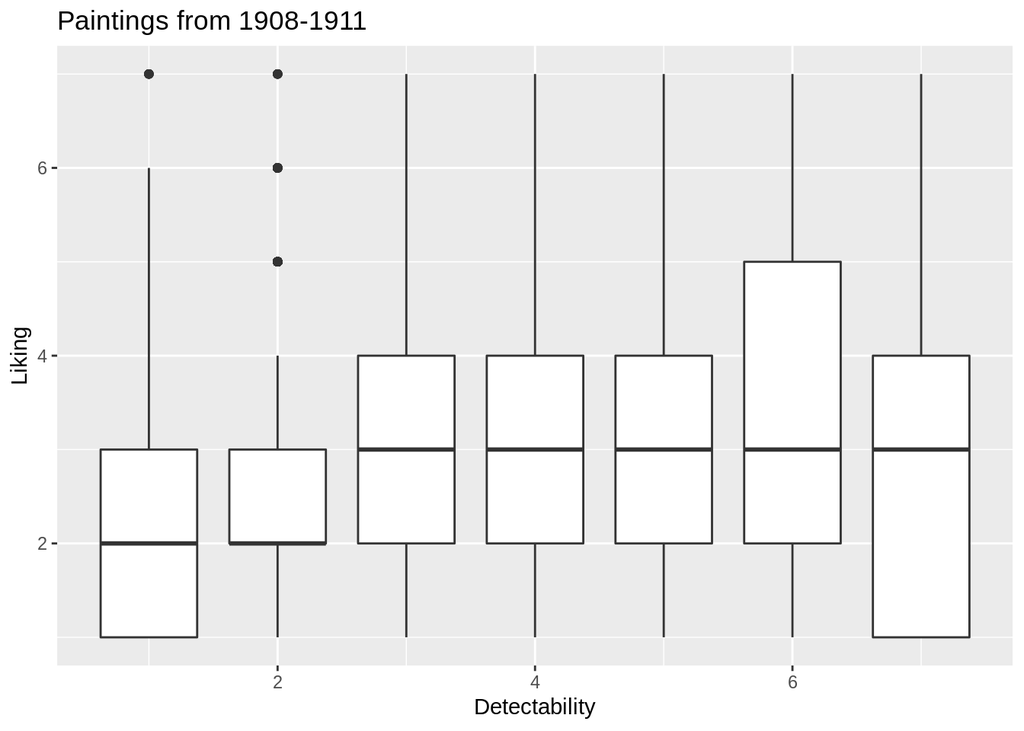

```r
data1 <- d %>% filter(date <= 1911)
data2 <- d %>% filter(date >= 1912, date <= 1915)
data3 <- d %>% filter(date >= 1916)

ggplot(data1, aes(x = detectability, y = liking, group = detectability)) + geom_boxplot() + labs(x = "Detectability", y = "Liking", title = "Paintings from 1908-1911")
```

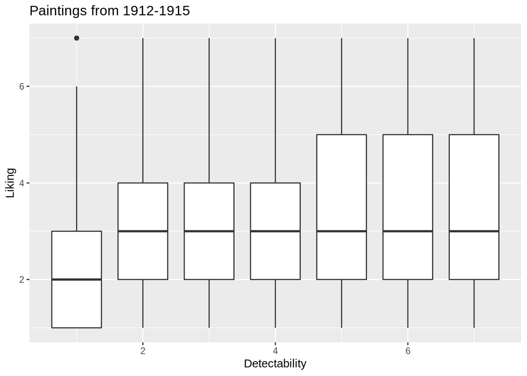

```r
ggplot(data2, aes(x = detectability, y = liking, group = detectability)) + geom_boxplot() + labs(x = "Detectability", y = "Liking", title = "Paintings from 1912-1915")
```

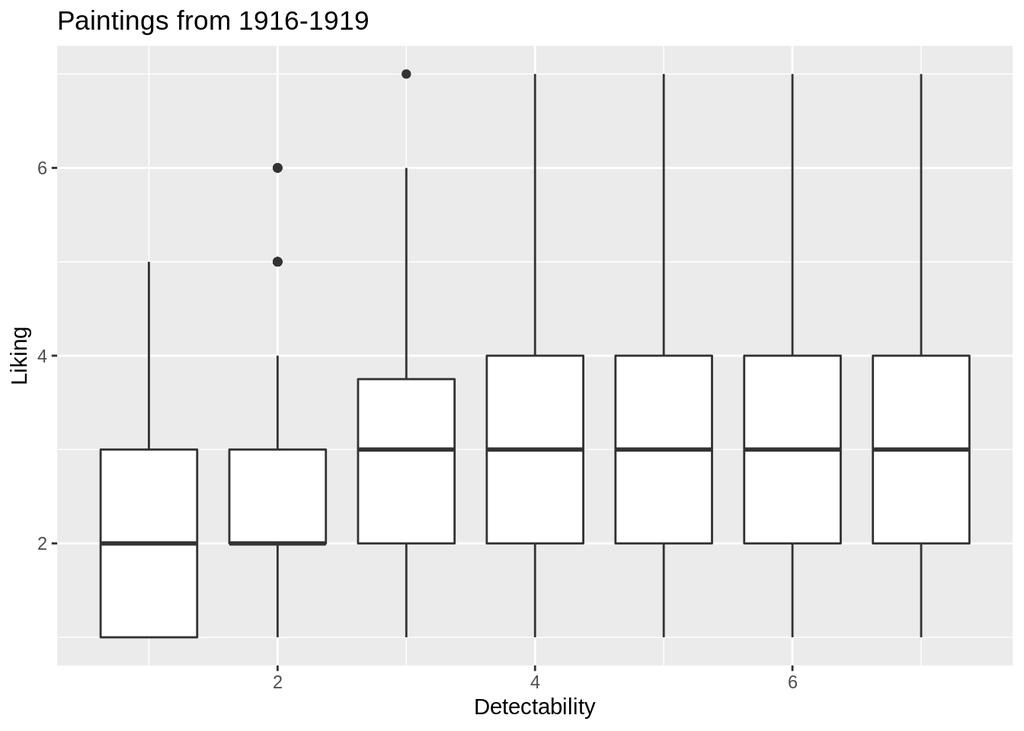

```r
ggplot(data3, aes(x = detectability, y = liking, group = detectability)) + geom_boxplot() + labs(x = "Detectability", y = "Liking", title = "Paintings from 1916-1919")
```

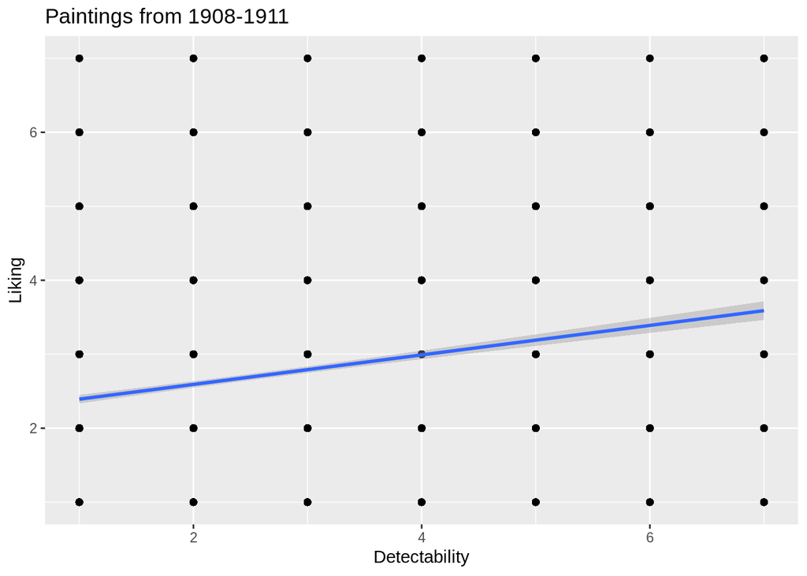

```r
ggplot(data1, aes(x = detectability, y = liking)) + geom_point() + geom_smooth(method = "lm") + labs(x = "Detectability", y = "Liking", title = "Paintings from 1908-1911")
```

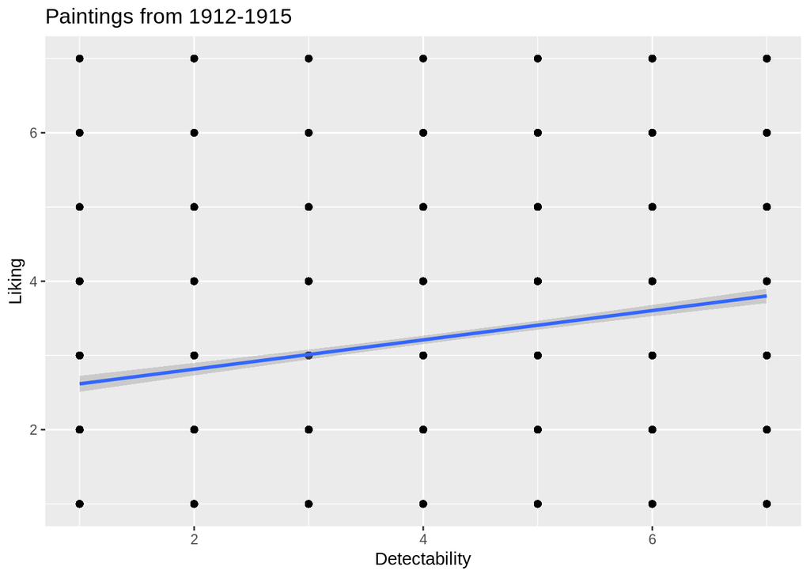

```r
ggplot(data2, aes(x = detectability, y = liking)) + geom_point() + geom_smooth(method = "lm") + labs(x = "Detectability", y = "Liking", title = "Paintings from 1912-1915")
```

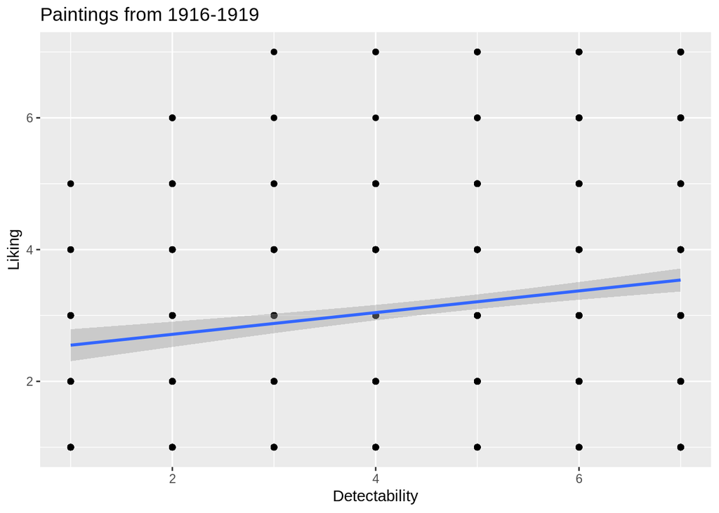

```r
ggplot(data3, aes(x = detectability, y = liking)) + geom_point() + geom_smooth(method = "lm") + labs(x = "Detectability", y = "Liking", title = "Paintings from 1916-1919")
```

prepare the data for the analysis:

```r
d = mutate(d,
           liking = factor(liking, ordered = T),
           detectability = factor(detectability, ordered = T),
           color = factor(color),
           color2 = factor(color2),
           artist = factor(artist)
           )
glimpse(d)
```

```
## Observations: 7,680
## Variables: 8
## $ submissionID  <dbl> 551, 551, 551, 551, 551, 551, 551, 551, 551, 551, …
## $ pictureNumber <dbl> 1, 2, 3, 4, 5, 6, 7, 8, 9, 10, 11, 12, 13, 14, 15,…
## $ artist        <fct> B, B, B, B, B, B, B, B, B, P, B, P, P, P, P, P, P,…
## $ date          <dbl> 1909, 1909, 1910, 1910, 1910, 1910, 1913, 1909, 19…
## $ color         <fct> colored, colored, colored, colored, colored, color…
## $ color2        <fct> colored, sepia, sepia, sepia, colored, sepia, colo…
## $ detectability <ord> 6, 5, 4, 2, 3, 2, 2, 6, 2, 2, 5, 2, 4, 4, 7, 2, 1,…
## $ liking        <ord> 2, 2, 2, 2, 2, 5, 2, 2, 2, 2, 1, 2, 2, 2, 3, 3, 4,…
```

ANALYSIS

Pearon correlation of liking and detectability:

```r
cor(as.numeric(d$liking), as.numeric(d$detectability))
```

```
## [1] 0.2828698
```

```r
m1 = brm(formula = liking ~ detectability,
         data = d,
         family = cumulative("logit"))

print(m1)
```

```
##  Family: cumulative
##   Links: mu = logit; disc = identity
## Formula: liking ~ detectability
##    Data: d (Number of observations: 7680)
## Samples: 4 chains, each with iter = 2000; warmup = 1000; thin = 1;
##          total post-warmup samples = 4000
##
## Population-Level Effects:
##                 Estimate Est.Error l-95% CI u-95% CI Eff.Sample Rhat
## Intercept[1]       -1.75      0.03    -1.81    -1.69       3207 1.00
## Intercept[2]       -0.45      0.03    -0.50    -0.40       4627 1.00
## Intercept[3]        0.65      0.03     0.60     0.70       5216 1.00
## Intercept[4]        1.55      0.03     1.49     1.61       5042 1.00
## Intercept[5]        2.56      0.05     2.47     2.65       6075 1.00
## Intercept[6]        3.73      0.08     3.59     3.89       6150 1.00
## detectability.L     1.29      0.06     1.18     1.41       5425 1.00
## detectability.Q    -0.56      0.06    -0.67    -0.45       5797 1.00
## detectability.C     0.05      0.06    -0.06     0.16       5501 1.00
## detectabilityE4    -0.11      0.06    -0.22    -0.01       5522 1.00
## detectabilityE5     0.04      0.06    -0.06     0.15       6492 1.00
## detectabilityE6    -0.05      0.06    -0.16     0.06       6439 1.00
##
## Samples were drawn using sampling(NUTS). For each parameter, Eff.Sample
## is a crude measure of effective sample size, and Rhat is the potential
## scale reduction factor on split chains (at convergence, Rhat = 1).
```

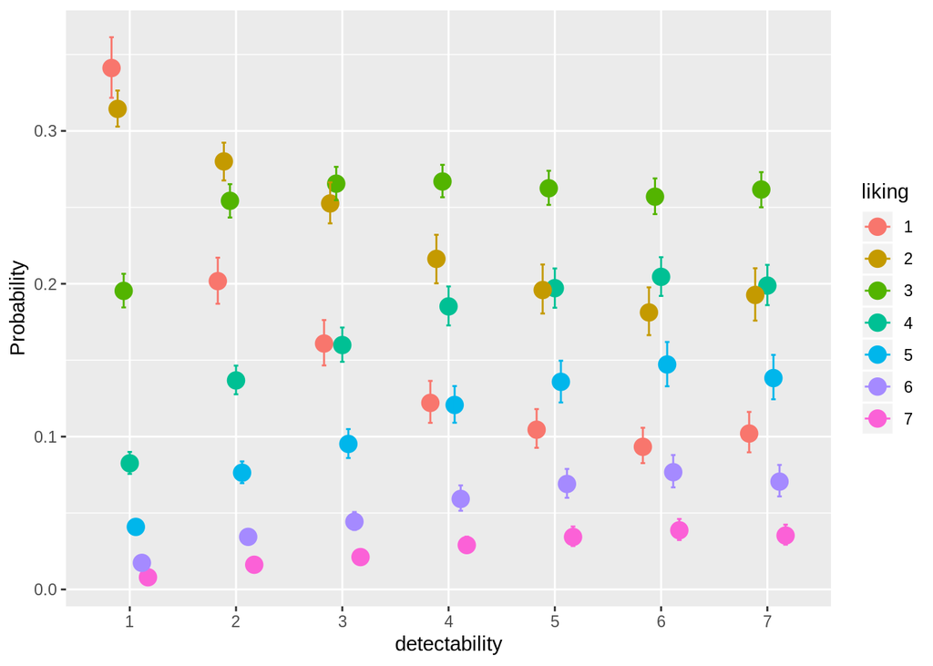

```r
marginal_effects(m1, categorical = T)
```

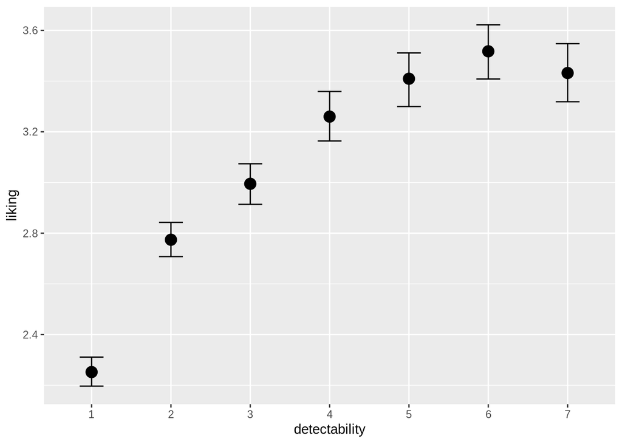

```r
marginal_effects(m1, categorical = F)
```

M2: Model that treats detectability as monotonic and includes random effects

```r
m2 = brm(formula = liking ~ mo(detectability) + (1|submissionID),
         data = d,
         family = "cumulative")

print(m2)
```

```
##  Family: cumulative
##   Links: mu = logit; disc = identity
## Formula: liking ~ mo(detectability) + (1 | submissionID)
##    Data: d (Number of observations: 7680)
## Samples: 4 chains, each with iter = 2000; warmup = 1000; thin = 1;
##          total post-warmup samples = 4000
##
## Group-Level Effects:
## ~submissionID (Number of levels: 64)
##               Estimate Est.Error l-95% CI u-95% CI Eff.Sample Rhat
## sd(Intercept)     1.36      0.13     1.13     1.62        243 1.01
##
## Population-Level Effects:
##                 Estimate Est.Error l-95% CI u-95% CI Eff.Sample Rhat
## Intercept[1]       -1.15      0.18    -1.51    -0.81        158 1.02
## Intercept[2]        0.52      0.18     0.16     0.86        160 1.03
## Intercept[3]        1.87      0.18     1.50     2.20        160 1.03
## Intercept[4]        2.92      0.18     2.54     3.25        164 1.03
## Intercept[5]        4.02      0.18     3.64     4.37        167 1.02
## Intercept[6]        5.25      0.19     4.85     5.60        181 1.02
## modetectability     0.28      0.01     0.25     0.30       2328 1.00
##
## Simplex Parameters:
##                     Estimate Est.Error l-95% CI u-95% CI Eff.Sample Rhat
## modetectability1[1]     0.26      0.04     0.18     0.33       2674 1.00
## modetectability1[2]     0.15      0.04     0.06     0.23       2186 1.00
## modetectability1[3]     0.19      0.05     0.09     0.29       2457 1.00
## modetectability1[4]     0.17      0.05     0.07     0.28       2899 1.00
## modetectability1[5]     0.12      0.05     0.02     0.23       3528 1.00
## modetectability1[6]     0.12      0.05     0.02     0.22       2496 1.00
##
## Samples were drawn using sampling(NUTS). For each parameter, Eff.Sample
## is a crude measure of effective sample size, and Rhat is the potential
## scale reduction factor on split chains (at convergence, Rhat = 1).
```

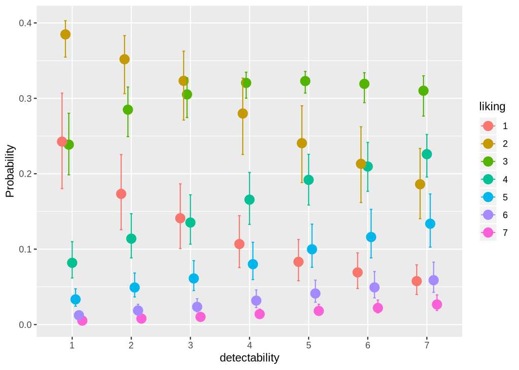

```r
marginal_effects(m2, categorical = T)
```

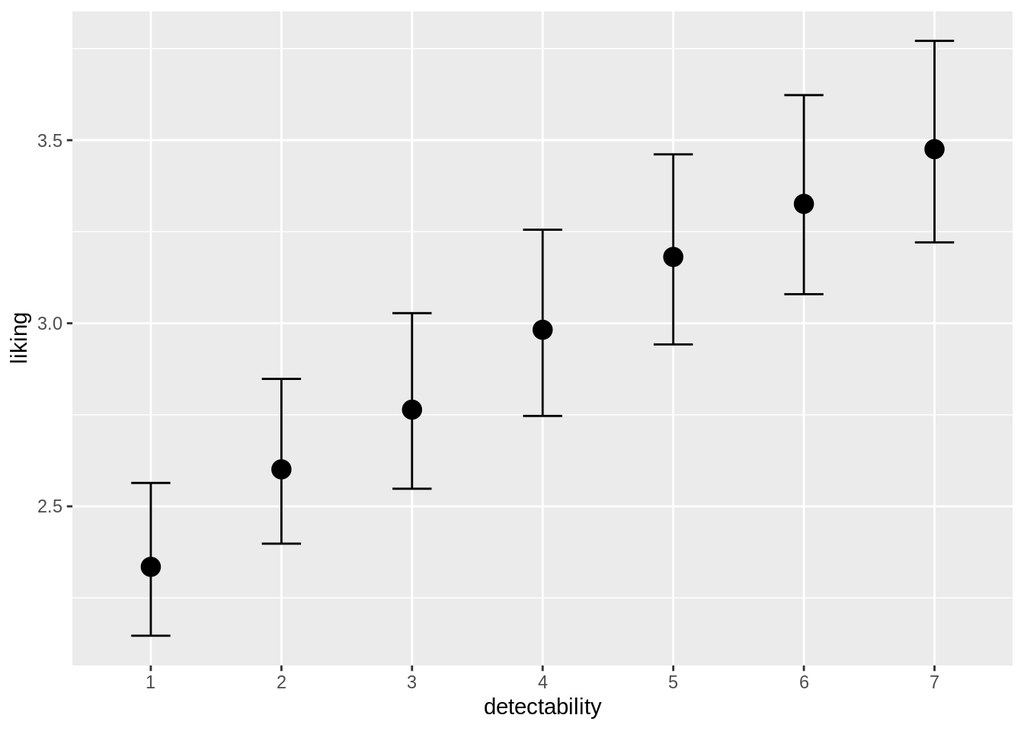

```r
marginal_effects(m2, categorical = F)
```

M3: Model that treats detectability as monotonic

```r
m3 = brm(formula = liking ~ mo(detectability),
         data = d,
         family = "cumulative")

print(m3)
```

```
##  Family: cumulative
##   Links: mu = logit; disc = identity
## Formula: liking ~ mo(detectability)
##    Data: d (Number of observations: 7680)
## Samples: 4 chains, each with iter = 2000; warmup = 1000; thin = 1;
##          total post-warmup samples = 4000
##
## Population-Level Effects:
##                 Estimate Est.Error l-95% CI u-95% CI Eff.Sample Rhat
## Intercept[1]       -0.67      0.05    -0.75    -0.58       3347 1.00
## Intercept[2]        0.64      0.05     0.55     0.72       3885 1.00
## Intercept[3]        1.74      0.05     1.64     1.83       4002 1.00
## Intercept[4]        2.64      0.05     2.53     2.74       4234 1.00
## Intercept[5]        3.64      0.06     3.51     3.77       5024 1.00
## Intercept[6]        4.82      0.09     4.65     4.99       4914 1.00
## modetectability     0.26      0.01     0.24     0.29       3598 1.00
##
## Simplex Parameters:
##                     Estimate Est.Error l-95% CI u-95% CI Eff.Sample Rhat
## modetectability1[1]     0.45      0.03     0.38     0.51       4150 1.00
## modetectability1[2]     0.17      0.04     0.09     0.26       4515 1.00
## modetectability1[3]     0.20      0.05     0.10     0.30       4396 1.00
## modetectability1[4]     0.10      0.05     0.01     0.19       3695 1.00
## modetectability1[5]     0.05      0.03     0.00     0.13       4962 1.00
## modetectability1[6]     0.03      0.02     0.00     0.09       4415 1.00
##
## Samples were drawn using sampling(NUTS). For each parameter, Eff.Sample
## is a crude measure of effective sample size, and Rhat is the potential
## scale reduction factor on split chains (at convergence, Rhat = 1).
```

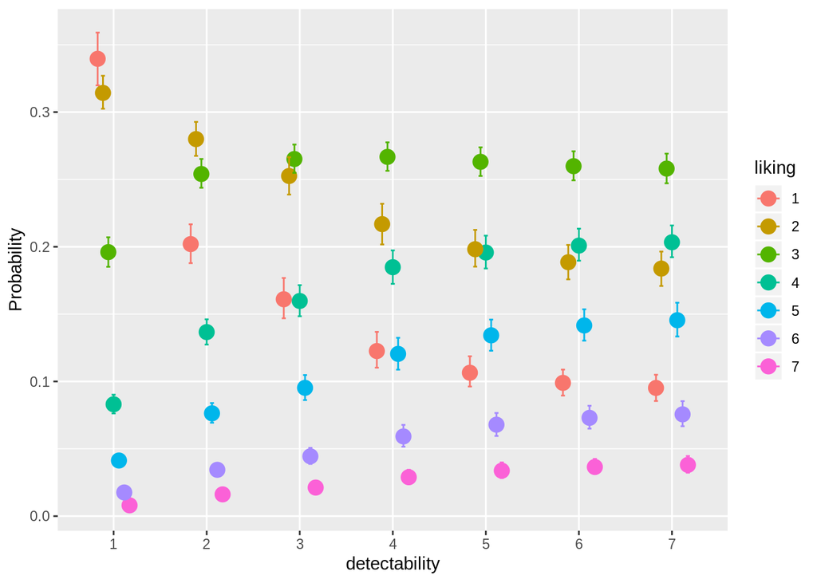

```r
marginal_effects(m3, categorical = T)
```

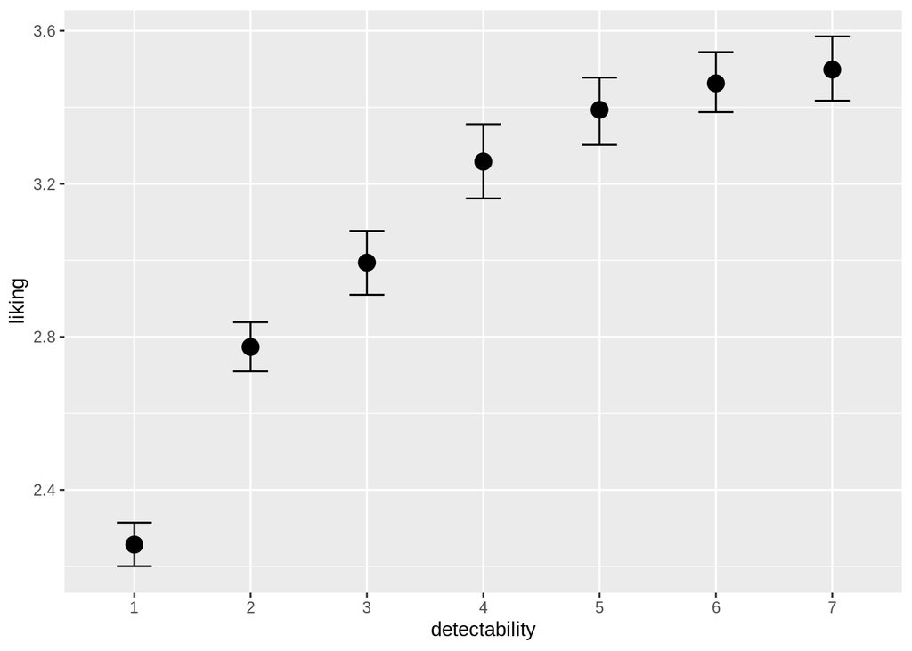

```r
marginal_effects(m3, categorical = F)
```

M4: Model that additionlly includes artist and color as an independent variable and includes random effects

```r
m4 = brm(formula = liking ~ mo(detectability) + artist + color2 + (1|submissionID),
         data = d,
         family = "cumulative")

print(m4)
```

```
##  Family: cumulative
##   Links: mu = logit; disc = identity
## Formula: liking ~ mo(detectability) + artist + color2 + (1 | submissionID)
##    Data: d (Number of observations: 7680)
## Samples: 4 chains, each with iter = 2000; warmup = 1000; thin = 1;
##          total post-warmup samples = 4000
##
## Group-Level Effects:
## ~submissionID (Number of levels: 64)
##               Estimate Est.Error l-95% CI u-95% CI Eff.Sample Rhat
## sd(Intercept)     1.41      0.14     1.17     1.71        278 1.02
##
## Population-Level Effects:
##                  Estimate Est.Error l-95% CI u-95% CI Eff.Sample Rhat
## Intercept[1]        -1.60      0.19    -1.97    -1.24        155 1.02
## Intercept[2]         0.10      0.19    -0.26     0.47        154 1.03
## Intercept[3]         1.49      0.19     1.12     1.85        154 1.03
## Intercept[4]         2.56      0.19     2.20     2.92        156 1.03
## Intercept[5]         3.69      0.19     3.30     4.07        161 1.02
## Intercept[6]         4.93      0.21     4.54     5.34        180 1.02
## artistG              0.50      0.06     0.38     0.62       2267 1.00
## artistP              0.02      0.05    -0.09     0.12       3032 1.00
## color2monochrome    -0.66      0.05    -0.76    -0.57       2800 1.00
## color2sepia         -0.32      0.06    -0.45    -0.20       2564 1.00
## modetectability      0.20      0.02     0.17     0.23       2958 1.00
##
## Simplex Parameters:
##                     Estimate Est.Error l-95% CI u-95% CI Eff.Sample Rhat
## modetectability1[1]     0.33      0.05     0.23     0.43       2529 1.00
## modetectability1[2]     0.15      0.06     0.04     0.27       2132 1.00
## modetectability1[3]     0.16      0.07     0.03     0.30       2146 1.00
## modetectability1[4]     0.15      0.07     0.03     0.30       2325 1.00
## modetectability1[5]     0.09      0.06     0.01     0.22       3710 1.00
## modetectability1[6]     0.11      0.06     0.01     0.23       3304 1.00
##
## Samples were drawn using sampling(NUTS). For each parameter, Eff.Sample
## is a crude measure of effective sample size, and Rhat is the potential
## scale reduction factor on split chains (at convergence, Rhat = 1).
```

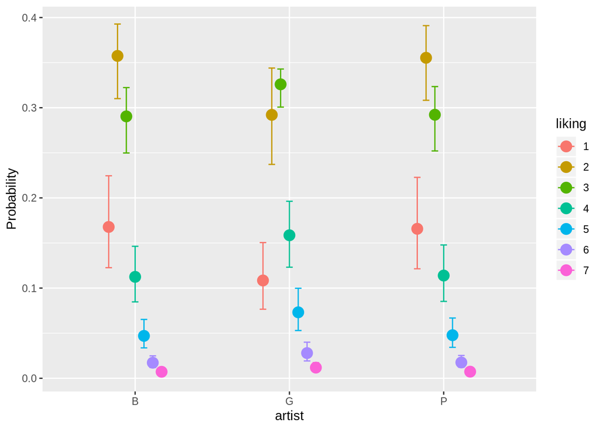

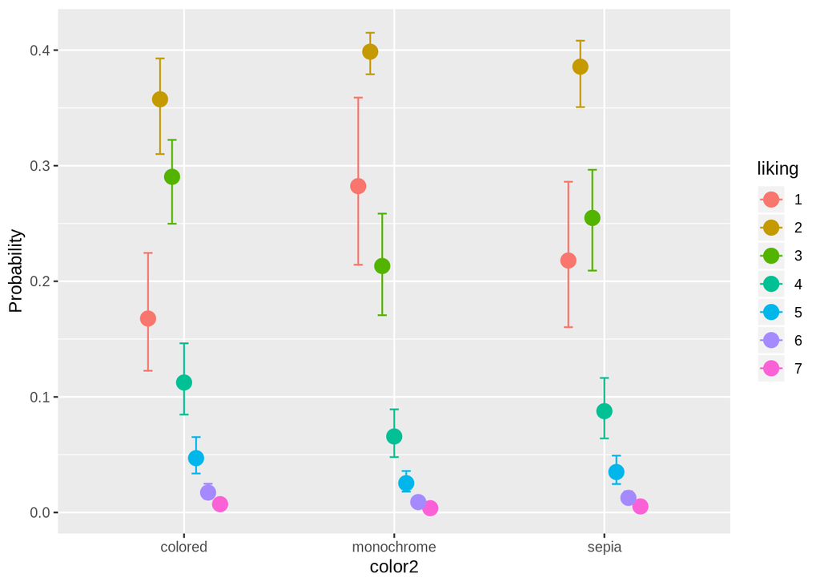

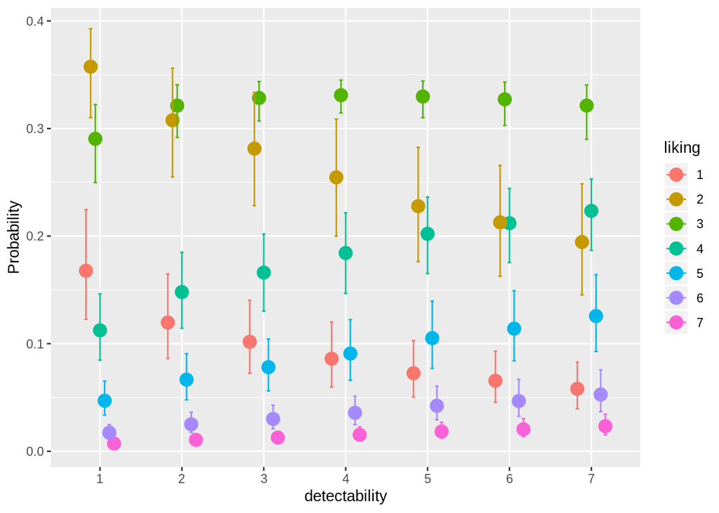

```r
marginal_effects(m4, categorical = T)
```